# Tutorial 9: Forecasting Distillation Dynamics with Long Short-Term Memory Networks

CHEE4003: Special Topics A - Artificial Intelligence in Chemical Engineering

Published

October 8, 2026

# Forecasting a dynamic process

In previous tutorials, machine learning models were trained using independent observations, where each prediction depended only on the current input values. However, many chemical processes are dynamic, meaning that future process behaviour depends on both current conditions and past operating history.

One example is a binary distillation column. As shown in Figure 1, changes in heating input affect vapour generation and the separation of material throughout the column. Consequently, boilup and product compositions depend on both current operating conditions and the state of the column built up over time.

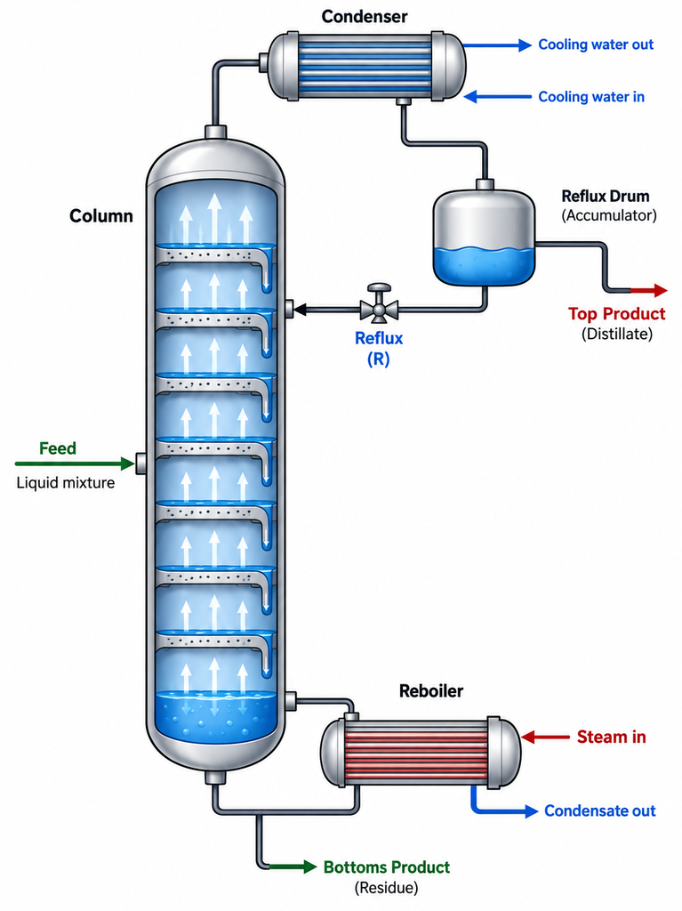

Figure 1: Schematic of a binary distillation column showing the major process streams and separation of components within the column.

To model this time-dependent behaviour, we will use a **long short-term memory (LSTM)** network. Unlike the neural network models explored in previous tutorials, LSTMs are designed to learn from sequential data and maintain information about previous observations. This makes them well suited for dynamic processes, where future behaviour depends on past operating history.

The dataset contains 3,000 equally spaced measurements collected over 24 hours from the simulated binary distillation process shown in Figure 1. Heating input is the operating signal. Boilup, distillate composition, and reboiler liquid composition are measured responses. We use the reboiler composition as the dataset’s measure of **bottoms composition**; the CSV does not contain a separate bottoms-product measurement. Feed-tray composition is an additional measured state that can help predict those responses.

Download the data to get started:

```
distillation_data_io.csv
```

```
Time (h),Heating Input (kJ/h),Boilup (mol/h),Distillate Composition,Reboiler Composition,Feed Tray Composition
0,17343.94814,364.9701261,0.971718524,0.575731362,0.688343198
0.008002668,17343.94814,351.0991043,0.971718855,0.57577652,0.688344403
0.016005335,17343.94814,351.1057362,0.971719826,0.575822553,0.688347522
0.024008003,17343.94814,351.112448,0.971721409,0.575869138,0.688351977
... (2997 more lines)
```

Below is a description of each of the variables in the dataset:

| Column | Role in this tutorial | Engineering interpretation |
| --- | --- | --- |
| `Time (h)` | Time index | Time since the beginning of the simulation |
| `Heating Input (kJ/h)` | History feature | Energy supplied to the reboiler; the operating signal |
| `Boilup (mol/h)` | History feature and target | Vapour generated in the column |
| `Reboiler Composition` | History feature and target | Reboiler liquid composition, used here for bottoms composition |
| `Distillate Composition` | History feature and target | Top-product composition |
| `Feed Tray Composition` | History feature | Internal composition that informs the forecast |

In this tutorial, the recent history of all five measurements provides information about both the operating conditions and the internal state of the column. The model forecasts future **boilup**, **bottoms composition** (the `Reboiler Composition` column), and **distillate composition**. Past values of a target may appear in the history window; only future values are used as targets.

The core activities are designed for approximately two hours.

| Section | Suggested time |
| --- | --- |
| Process dynamics, data, and sequence preparation | 28 min |
| Constructing an LSTM from basic PyTorch blocks | 20 min |
| Part 1: One-step-ahead LSTM and full-series assessment | 30 min |
| Part 2: Direct multi-horizon LSTM and trajectory assessment | 37 min |
| Synthesis | 5 min |

**NoteLearning objectives**

After completing this tutorial, you will be able to:

1. distinguish a dynamic process-forecasting problem from static regression;
2. create chronological train, validation, and test periods without leaking future observations into training;
3. transform process measurements into LSTM history windows and direct multi-horizon targets;
4. construct an LSTM cell from `nn.Linear`, `sigmoid`, `tanh`, and tensor operations;
5. train a one-step-ahead LSTM and inspect its predictions across the full training and test periods;
6. extend the LSTM to forecast 50 future measurements of boilup and both product compositions in one forward pass; and
7. join direct multi-output forecasts to their observed histories and compare horizon-wise error with a persistence baseline.

## PyTorch quickstart

This tutorial continues the PyTorch workflow introduced in Tutorial 8. You can run the code locally with PyTorch installed, or copy the student code cells into a Google Colab notebook. In Colab, download the CSV file above and upload it using the folder icon in the left sidebar before running the loading cell.

Before anything else, we need to have the correct libraries imported. Run the following cell before beginning the tasks.

```
import_libraries.py
```

```python
from pathlib import Path
import random

import matplotlib.pyplot as plt
import numpy as np
import pandas as pd
import torch
from torch import nn
from torch.utils.data import DataLoader, TensorDataset
```

To ensure reproducible results and automatically select the best available hardware, reuse the `set_seed()` and `select_device()` functions developed in the previous tutorial by copying them into your notebook.

When executed, the function automatically selects and reports the device that will be used for all subsequent computations.

print(f"Using device: {device}")

Using device: cpu

Before proceeding, define the following variables. These specify the dataset columns, prediction targets, and forecasting settings used throughout the tutorial.

```
specify_variables.py
```

```python
TIME_COLUMN = "Time (h)"
FEATURE_COLUMNS = [
    "Heating Input (kJ/h)",
    "Boilup (mol/h)",
    "Distillate Composition",
    "Reboiler Composition",
    "Feed Tray Composition",
]
TARGET_COLUMNS = [
    "Boilup (mol/h)",
    "Reboiler Composition",
    "Distillate Composition",
]
TARGET_LABELS = ["Boilup (mol/h)", "Bottoms composition", "Distillate composition"]
TARGET_FEATURE_INDICES = [
    FEATURE_COLUMNS.index(column) for column in TARGET_COLUMNS
]
LOOKBACK = 60
ONE_STEP_HORIZON = 1
HORIZON = 50
```

Here, `LOOKBACK` specifies the number of previous measurements provided to the model as input, `ONE_STEP_HORIZON` specifies a one-step-ahead prediction, and `HORIZON` specifies the number of future measurements predicted by the multi-horizon forecaster.

Next, use the `load_distillation_data()` function provided below to load the distillation dataset and perform a series of validation checks. The function confirms that all required columns are present, verifies that no missing values exist, and ensures that the measurements are ordered correctly in time.

```
load_distillation_data.py
```

```python
def load_distillation_data(file_path):
    """Load time-ordered distillation data and validate required columns."""
    data = pd.read_csv(file_path)
    required_columns = [TIME_COLUMN, *FEATURE_COLUMNS]
    missing_columns = set(required_columns).difference(data.columns)
    if missing_columns:
        raise ValueError(f"Missing columns: {sorted(missing_columns)}")
    if data[required_columns].isna().any().any():
        raise ValueError("The tutorial data must not contain missing values.")
    if not data[TIME_COLUMN].is_monotonic_increasing:
        raise ValueError("Time values must be in increasing order.")
    return data
```

After loading the dataset, use the commands below to confirm that the data have been loaded correctly and to calculate the sampling interval, lookback window, and forecast horizon used throughout the tutorial.

data = load_distillation_data("data/distillation_data_io.csv")

sample_interval_minutes = data[TIME_COLUMN].diff().median() * 60

print(f"Rows: {len(data):,}")

Rows: 3,000

print(f"Sampling interval: {sample_interval_minutes:.2f} minutes")

Sampling interval: 0.48 minutes

print(f"Lookback: {LOOKBACK * sample_interval_minutes:.1f} minutes")

Lookback: 28.8 minutes

print(f"Forecast horizon: {HORIZON * sample_interval_minutes:.1f} minutes")

Forecast horizon: 24.0 minutes

To better understand the behaviour of the distillation process, we will first visualise each variable as a function of time. The following function plots the operating signal and measured responses over the 24-hour simulation period.

```
plot_process_history.py
```

```python
def plot_process_history(data):
    """Plot the operating signal and measured responses against time."""
    figure, axes = plt.subplots(5, 1, figsize=(8, 11), sharex=True)
    variables = FEATURE_COLUMNS
    colours = ["tab:orange", "tab:blue", "tab:green", "tab:red", "tab:purple"]
    for axis, variable, colour in zip(axes, variables, colours):
        axis.plot(data[TIME_COLUMN], data[variable], color=colour, linewidth=1)
        axis.set_ylabel(variable)
        axis.grid(alpha=0.3)
    axes[-1].set_xlabel("Time (h)")
    figure.suptitle("Distillation Operating Signal and Measured Responses", y=0.99)
    figure.tight_layout()
    plt.show()
```

When you run this function, it should yield the following output:

plot_process_history(data)

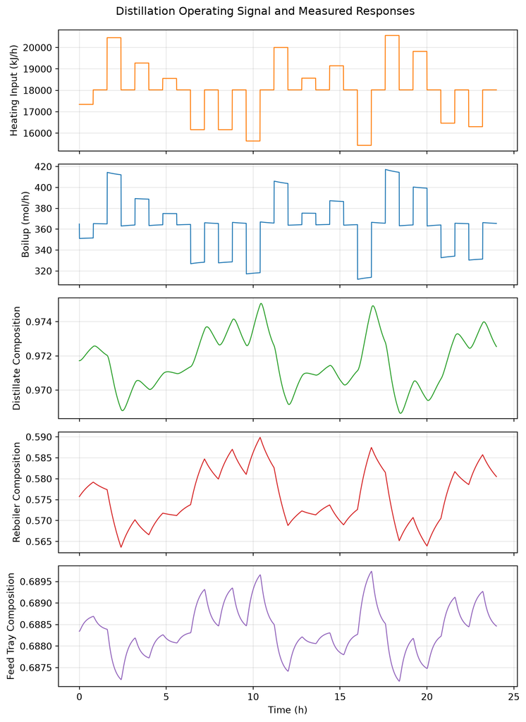

## From time series to supervised learning data

Considering that observations in a time series cannot be treated as independent samples. To train an LSTM, the process history must first be reorganised into input sequences and corresponding forecasting targets. An LSTM expects a sequence rather than one independent row at a time. For a forecast beginning at time $t$, the input is a history window

$$\mathbf{X}_t = [\mathbf{x}_{t-L}, \ldots, \mathbf{x}_{t-1}],$$

where $L=60$ is the lookback length.

**NoteLookback Window**

LSTMs do not receive a single observation as input. Instead, they are provided with a sequence of recent measurements called a **lookback window**. In this tutorial, each prediction uses the previous 60 measurements, corresponding to approximately 29 minutes of process history.

The target is a matrix of future boilup and product-composition measurements:

$$\mathbf{Y}_t =
\begin{bmatrix}
V(t) & x_B(t) & x_D(t) \\
V(t+1) & x_B(t+1) & x_D(t+1) \\
\vdots & \vdots & \vdots \\
V(t+H-1) & x_B(t+H-1) & x_D(t+H-1)
\end{bmatrix},$$

where $V$ is boilup in mol/h, $x_B$ is the reboiler liquid composition, $x_D$ is distillate composition, and $H=50$ is the forecast horizon. The forecasting task therefore maps an input tensor with shape `(batch, 60, 5)` to an output tensor with shape `(batch, 50, 3)`.

**ImportantAvoid Data Leakage**

Because the order of observations contains important information, the raw time series should not be randomly shuffled before splitting. Instead, the first 70% of observations are used for training, the next 15% for validation, and the final 15% for testing.

Randomly splitting generated windows would place overlapping histories and targets in different partitions, leading to unrealistically optimistic estimates of model performance. Any scaling transformations must therefore be fitted using only the training data to prevent future information from leaking into the preprocessing step.

The following functions perform the preprocessing required for time-series forecasting. They create chronological training, validation, and testing partitions, fit a standardisation transformation using only the training data, and apply the resulting scaling to the full dataset. Standardising each variable prevents boilup’s larger numerical units from dominating the training loss. Later, we calculate RMSE separately for each target in its original units.

```
chronological_boundaries.py
```

```python
def chronological_boundaries(n_rows, train_fraction=0.70,
                             validation_fraction=0.15):
    """Return exclusive end indices for chronological data partitions."""
    if not 0 < train_fraction < 1:
        raise ValueError("train_fraction must be between 0 and 1.")
    if not 0 < validation_fraction < 1 - train_fraction:
        raise ValueError("validation_fraction must leave a test period.")
    train_end = int(n_rows * train_fraction)
    validation_end = train_end + int(n_rows * validation_fraction)
    return train_end, validation_end


def fit_standardizer(training_values):
    """Return feature-wise statistics fitted only to training data."""
    mean = training_values.mean(axis=0)
    standard_deviation = training_values.std(axis=0)
    if np.any(standard_deviation == 0):
        raise ValueError("A constant feature cannot be standardised.")
    return mean, standard_deviation


def standardize(values, mean, standard_deviation):
    """Apply supplied training-period statistics to an array."""
    return (values - mean) / standard_deviation
```

Use the functions defined above to create the chronological data partitions and standardise the process variables.

train_end, validation_end = chronological_boundaries(len(data))

feature_values = data[FEATURE_COLUMNS].to_numpy(dtype=np.float64)

feature_mean, feature_standard_deviation = fit_standardizer(

feature_values[:train_end])

scaled_feature_values = standardize(

feature_values, feature_mean, feature_standard_deviation).astype(np.float32)

scaled_target_values = scaled_feature_values[:, TARGET_FEATURE_INDICES]

target_mean = feature_mean[TARGET_FEATURE_INDICES]

target_standard_deviation = feature_standard_deviation[TARGET_FEATURE_INDICES]

assert train_end == 2100

assert validation_end == 2550

np.testing.assert_allclose(

scaled_target_values[0], scaled_feature_values[0, [1, 3, 2]]

)

np.testing.assert_allclose(

scaled_feature_values[:train_end].mean(axis=0),

np.zeros(len(FEATURE_COLUMNS)), atol=1e-5)

The assertions verify that the expected training and validation boundaries have been created and that the training data have been centred correctly after standardisation.

### Task 1 : Create direct multi-horizon sequences

Write `make_direct_horizon_windows`. For every valid forecast start, it must return a history window of `lookback` feature rows, a matrix containing the next `horizon` scaled values for every target, and the integer index at which that target matrix begins.

**TipImplementation guidance**

The first history window is `features[0:lookback]`. Its target matrix begins immediately afterwards at `target[lookback:lookback + horizon]`. For every later window, move both slices forward by one row. There are `len(features) - lookback - horizon + 1` complete windows.

```
make_direct_horizon_windows.py
```

```python
def make_direct_horizon_windows(features, target, lookback, horizon):
    """
    Convert sequential features and multiple targets into direct forecast examples.

    Parameters
    ----------
    features : np.ndarray
        Array with shape ``(time, n_features)``.
    target : np.ndarray
        Array with shape ``(time, n_targets)`` containing scaled targets.
    lookback : int
        Number of prior rows in each history window.
    horizon : int
        Number of future target values predicted by each example.

    Returns
    -------
    X : torch.Tensor
        History windows with shape ``(examples, lookback, n_features)``.
    y : torch.Tensor
        Forecast targets with shape ``(examples, horizon, n_targets)``.
    forecast_starts : np.ndarray
        Index of the first target value for each example.
    """
```

X_all, y_all, forecast_starts = make_direct_horizon_windows(

scaled_feature_values, scaled_target_values, LOOKBACK, HORIZON

)

train_mask = forecast_starts + HORIZON <= train_end

validation_mask = ((forecast_starts >= train_end)

& (forecast_starts + HORIZON <= validation_end))

test_mask = forecast_starts >= validation_end

X_train, y_train = X_all[train_mask], y_all[train_mask]

X_validation, y_validation = X_all[validation_mask], y_all[validation_mask]

X_test, y_test = X_all[test_mask], y_all[test_mask]

print(f"Training windows: {len(X_train):,}")

Training windows: 1,991

print(f"Validation windows: {len(X_validation):,}")

Validation windows: 401

print(f"Test windows: {len(X_test):,}")

Test windows: 401

print(f"Input shape: {tuple(X_train.shape[1:])}")

Input shape: (60, 5)

print(f"Target shape: {tuple(y_train.shape[1:])}")

Target shape: (50, 3)

**Callout-answerAnswer**

```
make_direct_horizon_windows.py
```

```python
def make_direct_horizon_windows(features, target, lookback, horizon):
    if features.ndim != 2:
        raise ValueError("features must have shape (time, n_features).")
    if target.ndim != 2:
        raise ValueError("target must have shape (time, n_targets).")
    if len(features) != len(target):
        raise ValueError("features and target must have the same length.")
    if lookback < 1 or horizon < 1:
        raise ValueError("lookback and horizon must be positive integers.")

    n_windows = len(features) - lookback - horizon + 1
    if n_windows < 1:
        raise ValueError("The series is too short for this window and horizon.")

    X = np.empty((n_windows, lookback, features.shape[1]), dtype=np.float32)
    y = np.empty((n_windows, horizon, target.shape[1]), dtype=np.float32)
    forecast_starts = np.empty(n_windows, dtype=int)
    for window_index in range(n_windows):
        target_start = window_index + lookback
        X[window_index] = features[window_index:target_start]
        y[window_index] = target[target_start:target_start + horizon]
        forecast_starts[window_index] = target_start

    return torch.from_numpy(X), torch.from_numpy(y), forecast_starts
```

The historical measurements immediately before a validation or test forecast are realistic information: they would already be known when a forecast is issued. The target values themselves remain entirely within their assigned period.

```
make_loader.py
```

```python
def make_loader(features, target, batch_size, shuffle):
    """Create a PyTorch data loader from forecast features and targets."""
    return DataLoader(TensorDataset(features, target), batch_size=batch_size,
                      shuffle=shuffle)


BATCH_SIZE = 128
train_loader = make_loader(X_train, y_train, BATCH_SIZE, shuffle=True)
validation_loader = make_loader(X_validation, y_validation, BATCH_SIZE,
                                shuffle=False)
test_loader = make_loader(X_test, y_test, BATCH_SIZE, shuffle=False)
```

The completed **training** windows can and should be shuffled each epoch. `TensorDataset` keeps every history window paired with its own 50-by-3 forecast target while `DataLoader(..., shuffle=True)` changes only the order in which complete training examples are presented. Validation and test windows remain ordered.

## Constructing an LSTM from basic neural-network blocks

PyTorch provides the optimised `nn.LSTM` module. In this tutorial, however, we will construct one LSTM cell directly from basic `nn` building blocks. This makes the information flow visible while PyTorch autograd still calculates the gradients required for training.

At every time step, the LSTM receives the current feature vector $\mathbf{x}_t$, previous hidden state $\mathbf{h}_{t-1}$, and previous cell state $\mathbf{c}_{t-1}$. A linear layer produces four gate vectors:

$$\begin{aligned}
\mathbf{i}_t &= \sigma(\mathbf{W}[\mathbf{x}_t, \mathbf{h}_{t-1}] + \mathbf{b})_i, \\
\mathbf{f}_t &= \sigma(\mathbf{W}[\mathbf{x}_t, \mathbf{h}_{t-1}] + \mathbf{b})_f, \\
\mathbf{g}_t &= \tanh(\mathbf{W}[\mathbf{x}_t, \mathbf{h}_{t-1}] + \mathbf{b})_g, \\
\mathbf{o}_t &= \sigma(\mathbf{W}[\mathbf{x}_t, \mathbf{h}_{t-1}] + \mathbf{b})_o, \\
\mathbf{c}_t &= \mathbf{f}_t \odot \mathbf{c}_{t-1} + \mathbf{i}_t \odot \mathbf{g}_t, \\
\mathbf{h}_t &= \mathbf{o}_t \odot \tanh(\mathbf{c}_t).
\end{aligned}$$

The input, forget, and output gates use the sigmoid function and therefore take values between zero and one. The candidate state uses `tanh` and takes values between negative one and one. The notation `[x, h]` means concatenation, so one linear layer with `4 * hidden_size` outputs can calculate all four pre-activation gate vectors.

### Task 2 : Build one manual LSTM cell

Complete `ManualLSTMCell.forward`. Concatenate the input and previous hidden state, apply `self.gate_layer`, split the result into input, forget, candidate, and output gates, then calculate the next cell and hidden states using the equations above.

```
manual_lstm_cell.py
```

```python
class ManualLSTMCell(nn.Module):
    """One LSTM cell built from a linear layer and element-wise operations."""

    def __init__(self, input_size, hidden_size):
        super().__init__()
        self.hidden_size = hidden_size
        self.gate_layer = nn.Linear(
            input_size + hidden_size, 4 * hidden_size
        )

    def forward(self, x_t, h_previous, c_previous):
        """
        Update one LSTM state for a batch of current input vectors.

        Returns updated hidden and cell states, each with shape
        ``(batch, hidden_size)``.
        """
```

manual_cell = ManualLSTMCell(input_size=len(FEATURE_COLUMNS), hidden_size=8)

next_hidden, next_state = manual_cell(

torch.randn(4, len(FEATURE_COLUMNS)), torch.zeros(4, 8), torch.zeros(4, 8)

)

print(f"Manual LSTM hidden-state shape: {tuple(next_hidden.shape)}")

Manual LSTM hidden-state shape: (4, 8)

print(f"Manual LSTM cell-state shape: {tuple(next_state.shape)}")

Manual LSTM cell-state shape: (4, 8)

**Callout-answerAnswer**

```
manual_lstm_cell.py
```

```python
class ManualLSTMCell(nn.Module):
    """One LSTM cell built from a linear layer and element-wise operations."""

    def __init__(self, input_size, hidden_size):
        super().__init__()
        self.hidden_size = hidden_size
        self.gate_layer = nn.Linear(
            input_size + hidden_size, 4 * hidden_size
        )

    def forward(self, x_t, h_previous, c_previous):
        combined = torch.cat((x_t, h_previous), dim=1)
        input_gate, forget_gate, candidate_gate, output_gate = (
            self.gate_layer(combined).chunk(4, dim=1)
        )
        input_gate = torch.sigmoid(input_gate)
        forget_gate = torch.sigmoid(forget_gate)
        candidate_gate = torch.tanh(candidate_gate)
        output_gate = torch.sigmoid(output_gate)
        c_next = forget_gate * c_previous + input_gate * candidate_gate
        h_next = output_gate * torch.tanh(c_next)
        return h_next, c_next
```

# Part 1: One-step-ahead LSTM forecasting

The first model predicts only the next measurement of each target. This is a one-step-ahead forecast: every history window of 60 measurements maps to one three-value target vector. It gives one unambiguous prediction for each forecast time, so we can plot predictions against observations across the complete training and test periods.

## Prepare one-step examples

`make_direct_horizon_windows` already accepts a horizon length. Setting `horizon=1` constructs one-step examples, then removing the length-one horizon dimension gives targets with shape `(examples, 3)`.

```
prepare_one_step_examples.py
```

```python
X_one_step_all, y_one_step_all, one_step_forecast_starts = (
    make_direct_horizon_windows(
        scaled_feature_values, scaled_target_values, LOOKBACK, ONE_STEP_HORIZON
    )
)
y_one_step_all = y_one_step_all[:, 0, :]
one_step_train_mask = one_step_forecast_starts + ONE_STEP_HORIZON <= train_end
one_step_validation_mask = (
    (one_step_forecast_starts >= train_end)
    & (one_step_forecast_starts + ONE_STEP_HORIZON <= validation_end)
)
one_step_test_mask = one_step_forecast_starts >= validation_end

X_one_step_train = X_one_step_all[one_step_train_mask]
y_one_step_train = y_one_step_all[one_step_train_mask]
X_one_step_validation = X_one_step_all[one_step_validation_mask]
y_one_step_validation = y_one_step_all[one_step_validation_mask]
X_one_step_test = X_one_step_all[one_step_test_mask]
y_one_step_test = y_one_step_all[one_step_test_mask]

one_step_train_loader = make_loader(
    X_one_step_train, y_one_step_train, BATCH_SIZE, shuffle=True
)
one_step_validation_loader = make_loader(
    X_one_step_validation, y_one_step_validation, BATCH_SIZE, shuffle=False
)
one_step_test_loader = make_loader(
    X_one_step_test, y_one_step_test, BATCH_SIZE, shuffle=False
)
print(f"One-step input shape:  {tuple(X_one_step_train.shape[1:])}")
print(f"One-step target shape: {tuple(y_one_step_train.shape[1:])}")
print(f"One-step train windows: {len(X_one_step_train):,}")
print(f"One-step test windows:  {len(X_one_step_test):,}")
```

Output

```
One-step input shape:  (60, 5)
One-step target shape: (3,)
One-step train windows: 2,040
One-step test windows:  450
```

## A one-step multi-output LSTM

The encoder is the same manual LSTM cell used above. Its output head has three units: one prediction each for boilup, bottoms composition, and distillate composition at the next measurement time.

### Task 3 : Build the one-step LSTM

Complete `OneStepLSTM.forward`. Begin with zero hidden and cell states for the current batch. Apply `self.cell` to each time step of `sequence`, then use `self.output_head` to convert the final hidden state into the next three target predictions.

```
one_step_lstm.py
```

```python
class OneStepLSTM(nn.Module):
    """Manual LSTM encoder followed by a one-step target output head."""

    def __init__(self, input_size, hidden_size, target_size):
        super().__init__()
        self.hidden_size = hidden_size
        self.cell = ManualLSTMCell(input_size, hidden_size)
        self.output_head = nn.Linear(hidden_size, target_size)

    def forward(self, sequence):
        """Return the next target vector with shape ``(batch, target_size)``."""
```

one_step_shape_model = OneStepLSTM(

input_size=len(FEATURE_COLUMNS), hidden_size=16,

target_size=len(TARGET_COLUMNS)

)

one_step_shape_forecast = one_step_shape_model(

torch.randn(5, LOOKBACK, len(FEATURE_COLUMNS))

)

**Callout-answerAnswer**

```
one_step_lstm.py
```

```python
class OneStepLSTM(nn.Module):
    """Manual LSTM encoder followed by a one-step target output head."""

    def __init__(self, input_size, hidden_size, target_size):
        super().__init__()
        self.hidden_size = hidden_size
        self.cell = ManualLSTMCell(input_size, hidden_size)
        self.output_head = nn.Linear(hidden_size, target_size)

    def forward(self, sequence):
        batch_size = sequence.shape[0]
        h_current = sequence.new_zeros(batch_size, self.hidden_size)
        c_current = sequence.new_zeros(batch_size, self.hidden_size)
        for time_step in range(sequence.shape[1]):
            h_current, c_current = self.cell(
                sequence[:, time_step, :], h_current, c_current
            )
        return self.output_head(h_current)
```

## Train and assess the one-step LSTM

The same MSE training loop works for a one-step target matrix `(batch, 3)` and for the later direct multi-horizon target matrix `(batch, 50, 3)`.

```
evaluate_loss.py
```

```python
def evaluate_loss(model, data_loader, loss_function, device):
    """Return the mean loss over a data loader without calculating gradients."""
    model.eval()
    total_loss = 0.0
    total_examples = 0
    with torch.no_grad():
        for feature_batch, target_batch in data_loader:
            feature_batch = feature_batch.to(device)
            target_batch = target_batch.to(device)
            batch_loss = loss_function(model(feature_batch), target_batch)
            total_loss += batch_loss.item() * len(feature_batch)
            total_examples += len(feature_batch)
    return total_loss / total_examples
```

### Task 4 : Train an LSTM forecaster

Write `train_model`. For each epoch, set the model to training mode, move each batch to `device`, calculate its forecast and MSE loss, clear old gradients, backpropagate, and update the optimiser. After the training batches, calculate and store the validation loss.

```
train_model.py
```

```python
def train_model(model, train_loader, validation_loader, device,
                epochs=40, learning_rate=3e-3):
    """Train an LSTM forecaster and return its training history."""
```

**Callout-answerAnswer**

```
train_model.py
```

```python
def train_model(model, train_loader, validation_loader, device,
                epochs=40, learning_rate=3e-3):
    loss_function = nn.MSELoss()
    optimiser = torch.optim.Adam(model.parameters(), lr=learning_rate)
    history = {"train_loss": [], "validation_loss": []}
    for epoch in range(epochs):
        model.train()
        total_loss = 0.0
        total_examples = 0
        for feature_batch, target_batch in train_loader:
            feature_batch = feature_batch.to(device)
            target_batch = target_batch.to(device)
            optimiser.zero_grad()
            loss = loss_function(model(feature_batch), target_batch)
            loss.backward()
            optimiser.step()
            total_loss += loss.item() * len(feature_batch)
            total_examples += len(feature_batch)
        train_loss = total_loss / total_examples
        validation_loss = evaluate_loss(
            model, validation_loader, loss_function, device
        )
        history["train_loss"].append(train_loss)
        history["validation_loss"].append(validation_loss)
        if (epoch + 1) % 10 == 0 or epoch == 0:
            print(
                f"Epoch {epoch + 1:2d}/{epochs}: "
                f"train MSE = {train_loss:.5f}, "
                f"validation MSE = {validation_loss:.5f}"
            )
    return history
```

```
plot_training_history.py
```

```python
def plot_training_history(history, title):
    """Plot training and validation MSE across model-training epochs."""
    epochs = np.arange(1, len(history["train_loss"]) + 1)
    plt.figure(figsize=(8, 4))
    plt.plot(epochs, history["train_loss"], label="Training MSE")
    plt.plot(epochs, history["validation_loss"], label="Validation MSE")
    plt.xlabel("Epoch")
    plt.ylabel("Scaled mean squared error")
    plt.title(title)
    plt.legend()
    plt.grid(alpha=0.3)
    plt.tight_layout()
    plt.show()


@torch.no_grad()
def predict(model, feature_tensor, device):
    """Return model forecasts on the CPU without tracking gradients."""
    model.eval()
    return model(feature_tensor.to(device)).cpu().numpy()


def inverse_target_scale(values, mean, standard_deviation):
    """Convert scaled target values back to their original units."""
    return values * standard_deviation + mean
```

ONE_STEP_HIDDEN_SIZE = 32

ONE_STEP_EPOCHS = 30

set_seed(42)

one_step_model = OneStepLSTM(

input_size=len(FEATURE_COLUMNS), hidden_size=ONE_STEP_HIDDEN_SIZE,

target_size=len(TARGET_COLUMNS)

).to(device)

one_step_history = train_model(

one_step_model, one_step_train_loader, one_step_validation_loader,

device, epochs=ONE_STEP_EPOCHS

)

Epoch 1/30: train MSE = 0.72703, validation MSE = 0.63749

Epoch 10/30: train MSE = 0.01098, validation MSE = 0.02336

Epoch 20/30: train MSE = 0.00290, validation MSE = 0.00824

Epoch 30/30: train MSE = 0.00113, validation MSE = 0.00363

plot_training_history(one_step_history, "One-Step LSTM Training History")

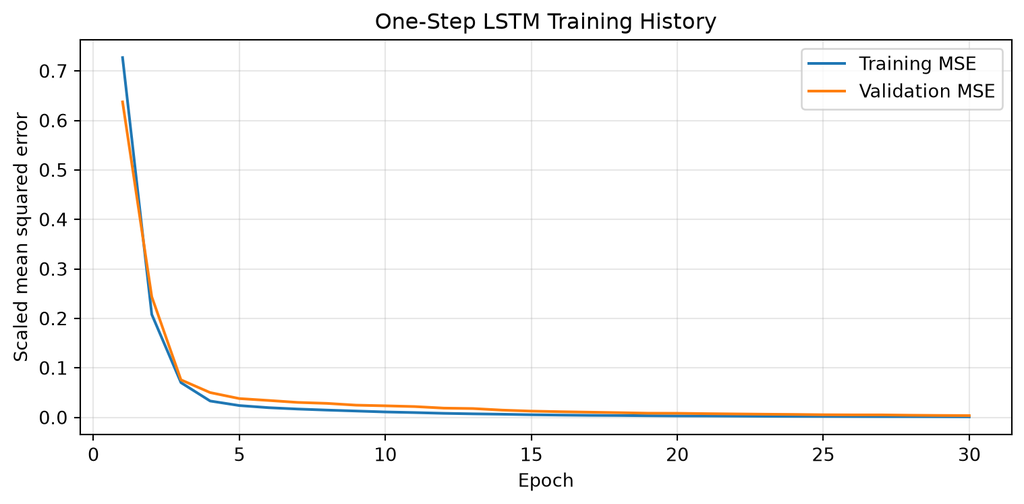

The figure below uses every one-step window from the training period and every one-step window from the test period. Each subplot is one target, so this is one figure containing the full one-step prediction record for boilup and both product compositions. The validation period is shaded and deliberately excluded from the displayed predictions.

```
plot_one_step_predictions.py
```

```python
def plot_one_step_predictions(train_times, train_actual, train_predicted,
                              test_times, test_actual, test_predicted,
                              target_names):
    """Plot one-step actual and predicted targets over train and test time."""
    figure, axes = plt.subplots(len(target_names), 1, figsize=(11, 8),
                                 sharex=True)
    for target_index, (axis, target_name) in enumerate(zip(axes, target_names)):
        axis.plot(train_times, train_actual[:, target_index], color="black",
                  linewidth=1, label="Observed training")
        axis.plot(train_times, train_predicted[:, target_index],
                  color="tab:blue", linewidth=1, label="Predicted training")
        axis.plot(test_times, test_actual[:, target_index], color="black",
                  linewidth=1, label="Observed test")
        axis.plot(test_times, test_predicted[:, target_index],
                  color="tab:green", linewidth=1, label="Predicted test")
        axis.axvspan(train_times[-1], test_times[0], color="tab:gray",
                    alpha=0.12, label="Validation period")
        axis.set_ylabel(target_name)
        axis.grid(alpha=0.3)
        axis.legend(loc="best", ncol=2)
    axes[-1].set_xlabel("Time (h)")
    figure.suptitle("One-Step LSTM Predictions Across Training and Test Periods")
    figure.tight_layout(rect=(0, 0, 1, 0.96))
    plt.show()
```

one_step_train_forecasts = inverse_target_scale(

predict(one_step_model, X_one_step_train, device),

target_mean, target_standard_deviation

)

one_step_test_forecasts = inverse_target_scale(

predict(one_step_model, X_one_step_test, device),

target_mean, target_standard_deviation

)

one_step_train_actual = inverse_target_scale(

y_one_step_train.numpy(), target_mean, target_standard_deviation

)

one_step_test_actual = inverse_target_scale(

y_one_step_test.numpy(), target_mean, target_standard_deviation

)

time_values = data[TIME_COLUMN].to_numpy()

one_step_train_times = time_values[one_step_forecast_starts[one_step_train_mask]]

one_step_test_times = time_values[one_step_forecast_starts[one_step_test_mask]]

plot_one_step_predictions(

one_step_train_times, one_step_train_actual, one_step_train_forecasts,

one_step_test_times, one_step_test_actual, one_step_test_forecasts,

TARGET_LABELS

)

print(f"One-step training predictions: {one_step_train_forecasts.shape}")

One-step training predictions: (2040, 3)

print(f"One-step test predictions: {one_step_test_forecasts.shape}")

One-step test predictions: (450, 3)

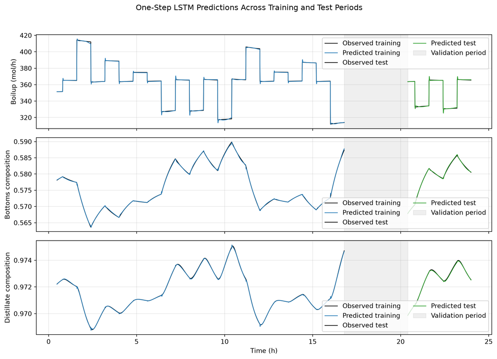

# Part 2: Direct multi-step LSTM forecasting

The one-step model makes one next-time prediction per history window. We now keep the same manual encoder but change its output head and targets so that each window produces a complete 50-step future trajectory in one forward pass.

## A direct multi-horizon LSTM forecaster

The cell above processes one time step. The forecasting model repeatedly applies the same cell to all 60 rows in one history window. The final hidden state summarises the recent process history. A linear output head converts that state into all 50 future values for each of the three targets at once.

This is a sequence-to-matrix architecture. It is direct because the output head produces every forecasted value in one call. The 150 predicted values are not passed back into the LSTM.

### Task 5 : Build the direct multi-horizon model

Complete `DirectHorizonLSTM.forward`. Begin with zero hidden and cell states for the current batch. Apply `self.cell` to each time step of `sequence`, then use `self.forecast_head` to convert the final hidden state into the forecast matrix.

```
direct_horizon_lstm.py
```

```python
class DirectHorizonLSTM(nn.Module):
    """Manual LSTM encoder followed by a direct multi-horizon output head."""

    def __init__(self, input_size, hidden_size, horizon, target_size):
        super().__init__()
        self.hidden_size = hidden_size
        self.horizon = horizon
        self.target_size = target_size
        self.cell = ManualLSTMCell(input_size, hidden_size)
        self.forecast_head = nn.Linear(hidden_size, horizon * target_size)

    def forward(self, sequence):
        """
        Forecast a complete future horizon from a batch of history windows.

        ``sequence`` has shape ``(batch, lookback, input_size)`` and the
        returned tensor must have shape ``(batch, horizon, target_size)``.
        """
```

shape_model = DirectHorizonLSTM(

input_size=len(FEATURE_COLUMNS), hidden_size=16, horizon=HORIZON,

target_size=len(TARGET_COLUMNS)

)

shape_forecast = shape_model(torch.randn(5, LOOKBACK, len(FEATURE_COLUMNS)))

print(f"Direct forecast shape: {tuple(shape_forecast.shape)}")

Direct forecast shape: (5, 50, 3)

**Callout-answerAnswer**

```
direct_horizon_lstm.py
```

```python
class DirectHorizonLSTM(nn.Module):
    """Manual LSTM encoder followed by a direct multi-horizon output head."""

    def __init__(self, input_size, hidden_size, horizon, target_size):
        super().__init__()
        self.hidden_size = hidden_size
        self.horizon = horizon
        self.target_size = target_size
        self.cell = ManualLSTMCell(input_size, hidden_size)
        self.forecast_head = nn.Linear(hidden_size, horizon * target_size)

    def forward(self, sequence):
        batch_size = sequence.shape[0]
        h_current = sequence.new_zeros(batch_size, self.hidden_size)
        c_current = sequence.new_zeros(batch_size, self.hidden_size)
        for time_step in range(sequence.shape[1]):
            h_current, c_current = self.cell(
                sequence[:, time_step, :], h_current, c_current
            )
        forecast = self.forecast_head(h_current)
        return forecast.reshape(batch_size, self.horizon, self.target_size)
```

## Train the direct multi-horizon LSTM

The same `train_model` function now compares an entire future matrix: 50 forecast positions by three targets, or 150 scaled values per example. The manual encoder remains unchanged; only the output head and target shape differ from the one-step model.

MULTI_STEP_HIDDEN_SIZE = 32

MULTI_STEP_EPOCHS = 40

set_seed(42)

multi_step_model = DirectHorizonLSTM(

input_size=len(FEATURE_COLUMNS),

hidden_size=MULTI_STEP_HIDDEN_SIZE,

horizon=HORIZON,

target_size=len(TARGET_COLUMNS),

).to(device)

multi_step_history = train_model(

multi_step_model, train_loader, validation_loader, device,

epochs=MULTI_STEP_EPOCHS,

)

Epoch 1/40: train MSE = 0.85930, validation MSE = 1.06123

Epoch 10/40: train MSE = 0.13775, validation MSE = 0.22189

Epoch 20/40: train MSE = 0.12126, validation MSE = 0.20604

Epoch 30/40: train MSE = 0.07528, validation MSE = 0.27120

Epoch 40/40: train MSE = 0.06776, validation MSE = 0.29293

plot_training_history(

multi_step_history, "Direct Multi-Horizon LSTM Training History"

)

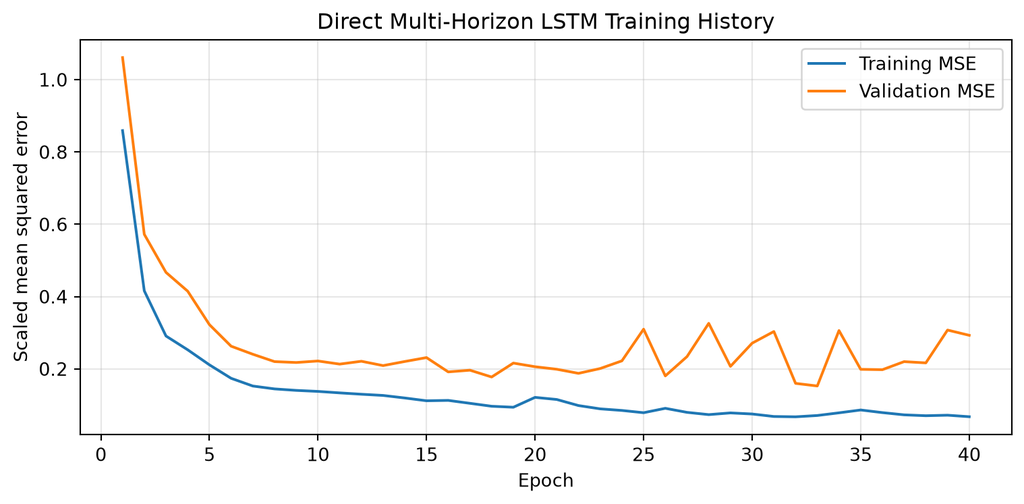

## Evaluating direct multi-output forecasts

The network predicts standardised values for boilup and both compositions because that is the scale used for training. We convert each target back to its original units before calculating engineering metrics and plotting forecasts. Boilup RMSE is in mol/h, while composition RMSE is in composition units; compare each target with its own persistence baseline rather than comparing RMSE magnitudes across targets.

A useful baseline is **persistence**: repeat the final measured value of each target for every point in the future horizon. A dynamic LSTM is useful only if it improves on this transparent assumption for the intended forecast horizon.

### Task 6 : Calculate horizon-wise RMSE

Write `horizon_rmse`. It should return one root mean squared error for every forecast position and every target. The first row measures one-sample-ahead error, while the final row measures error at the full 50-sample horizon.

```
horizon_rmse.py
```

```python
def horizon_rmse(actual, predicted):
    """
    Calculate RMSE independently at every forecast position.

    Parameters
    ----------
    actual, predicted : np.ndarray
        Arrays with the common shape ``(forecasts, horizon, n_targets)``.

    Returns
    -------
    np.ndarray
        RMSE values with shape ``(horizon, n_targets)``.
    """
```

**Callout-answerAnswer**

```
horizon_rmse.py
```

```python
def horizon_rmse(actual, predicted):
    if actual.shape != predicted.shape:
        raise ValueError("actual and predicted arrays must have the same shape.")
    if actual.ndim != 3:
        raise ValueError("actual and predicted arrays must be three-dimensional.")
    return np.sqrt(np.mean((actual - predicted) ** 2, axis=0))
```

### Task 7 : Plot the multi-output forecast, input history, and actual outputs

A direct forecast is easier to interpret when the 50 predicted values for every target are drawn after the observed target history that the LSTM received and alongside the actual held-out outputs. Write `plot_joined_forecast`. The function receives the `LOOKBACK` observed time points and target matrix, plus the 50 `forecast_times`, 50-by-3 `actual_values`, and 50-by-3 `forecast_values`. It must use `np.concatenate` to create joined actual and predicted matrices, then plot actual and predicted trajectories in one subplot per target.

**TipImplementation guidance**

For a forecast that begins at row `forecast_start`, the history is `time_values[forecast_start - LOOKBACK:forecast_start]`. The forecast time points are `time_values[forecast_start:forecast_start + HORIZON]`. Use `np.concatenate` once with `actual_values` and once with `forecast_values`. Loop over `target_names` to create one subplot for boilup, bottoms composition, and distillate composition. In each subplot, draw the joined actual trajectory in black and the joined LSTM trajectory in a second colour. A vertical line at `forecast_times[0]` makes the change from observation to prediction clear.

```
plot_joined_forecast.py
```

```python
def plot_joined_forecast(history_times, history_values, forecast_times,
                         actual_values, forecast_values, target_names):
    """Plot all direct forecasts against their histories and actual outputs.

    `forecast_times`, `actual_values`, and `forecast_values` must each contain
    the 50 points in the direct forecast horizon. The two value arrays have one
    column per target. Return the joined time, actual, and
    predicted target arrays after plotting them.
    """
```

**Callout-answerAnswer**

```
plot_joined_forecast.py
```

```python
def plot_joined_forecast(history_times, history_values, forecast_times,
                         actual_values, forecast_values, target_names):
    """Plot all direct forecasts against their histories and actual outputs."""
    if len(history_times) != history_values.shape[0]:
        raise ValueError("History times and values must have the same length.")
    if len(forecast_times) != actual_values.shape[0]:
        raise ValueError("Forecast times and actual values must have the same length.")
    if len(forecast_times) != forecast_values.shape[0]:
        raise ValueError("Forecast times and values must have the same length.")
    if actual_values.shape != forecast_values.shape:
        raise ValueError("Actual and forecast values must have the same shape.")
    if history_values.shape[1] != actual_values.shape[1]:
        raise ValueError("History and forecast values must have the same targets.")
    if history_values.shape[1] != len(target_names):
        raise ValueError("One target name is required for each target.")

    joined_times = np.concatenate((history_times, forecast_times))
    joined_actual_values = np.concatenate((history_values, actual_values))
    joined_forecast_values = np.concatenate((history_values, forecast_values))
    figure, axes = plt.subplots(len(target_names), 1, figsize=(9, 8),
                                 sharex=True)
    for target_index, (axis, target_name) in enumerate(zip(axes, target_names)):
        axis.plot(joined_times, joined_actual_values[:, target_index],
                  color="black", linewidth=2, label="Observed")
        axis.plot(joined_times, joined_forecast_values[:, target_index],
                  color="tab:green", linewidth=2, label="Direct LSTM")
        axis.axvline(forecast_times[0], color="tab:gray", linestyle="--",
                    label="Forecast begins")
        axis.set_ylabel(target_name)
        axis.grid(alpha=0.3)
        axis.legend(loc="best")
    axes[-1].set_xlabel("Time (h)")
    figure.suptitle("Direct Multi-Output Forecasts Joined to Input History")
    figure.tight_layout()
    plt.show()
    return joined_times, joined_actual_values, joined_forecast_values
```

time_values = data[TIME_COLUMN].to_numpy()

test_forecast_starts = forecast_starts[test_mask]

example_start = test_forecast_starts[example_index]

history_times = time_values[example_start - LOOKBACK:example_start]

history_values = data[TARGET_COLUMNS].to_numpy()[

example_start - LOOKBACK:example_start

]

forecast_times = time_values[example_start:example_start + HORIZON]

actual_values = actual_forecasts[example_index]

joined_times, joined_actual_values, joined_forecast_values = (

plot_joined_forecast(

history_times, history_values, forecast_times, actual_values,

lstm_forecasts[example_index], TARGET_LABELS

)

)

print(f"Observed history points: {len(history_times)}")

Observed history points: 60

print(f"Actual output shape: {actual_values.shape}")

Actual output shape: (50, 3)

print(f"Direct forecast points: {len(forecast_times)}")

Direct forecast points: 50

print(f"Joined trajectory points: {len(joined_times)}")

Joined trajectory points: 110

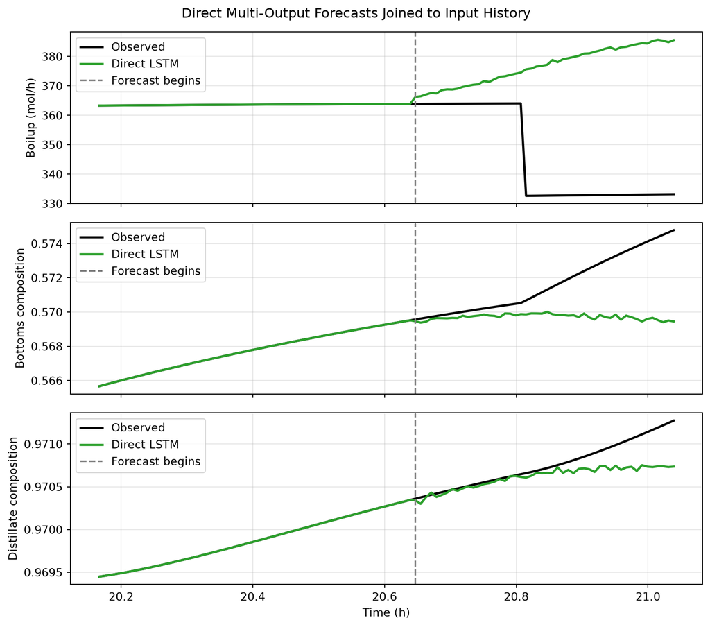

```
plot_horizon_rmse.py
```

```python
def plot_horizon_rmse(minutes_ahead, lstm_rmse, persistence_rmse, target_names):
    """Plot direct-LSTM and persistence RMSE for every target."""
    figure, axes = plt.subplots(len(target_names), 1, figsize=(9, 8),
                                 sharex=True)
    for target_index, (axis, target_name) in enumerate(zip(axes, target_names)):
        axis.plot(minutes_ahead, lstm_rmse[:, target_index],
                  color="tab:green", linewidth=2, label="Direct LSTM")
        axis.plot(minutes_ahead, persistence_rmse[:, target_index],
                  color="tab:gray", linestyle="--", linewidth=2,
                  label="Persistence baseline")
        axis.set_ylabel(f"RMSE: {target_name}")
        axis.legend(loc="best")
        axis.grid(alpha=0.3)
    axes[-1].set_xlabel("Minutes ahead")
    figure.suptitle("Forecast Error Across the Direct Multi-Output Horizon")
    figure.tight_layout()
    plt.show()
```

minutes_ahead = (np.arange(HORIZON) + 1) * sample_interval_minutes

plot_horizon_rmse(

minutes_ahead, lstm_horizon_rmse, persistence_horizon_rmse, TARGET_LABELS

)

for target_index, target_name in enumerate(TARGET_LABELS):

print(f"Mean LSTM RMSE for {target_name}: "

f"{lstm_horizon_rmse[:, target_index].mean():.5f}")

print(f"Mean persistence RMSE for {target_name}: "

f"{persistence_horizon_rmse[:, target_index].mean():.5f}")

Mean LSTM RMSE for Boilup (mol/h): 14.83822

Mean persistence RMSE for Boilup (mol/h): 15.81155

Mean LSTM RMSE for Bottoms composition: 0.00127

Mean persistence RMSE for Bottoms composition: 0.00178

Mean LSTM RMSE for Distillate composition: 0.00014

Mean persistence RMSE for Distillate composition: 0.00043

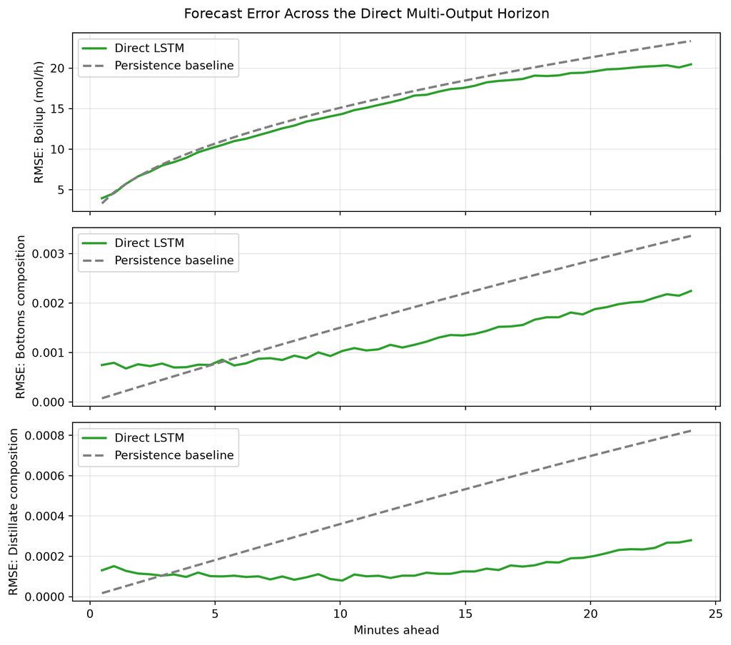

**NoteInterpreting the result**

The error at later forecast positions can be larger than the error immediately after the history window. This does not arise from recursively feeding predictions into the model: the direct LSTM predicts every position in one forward pass. Instead, longer-horizon changes can be harder to infer from past measurements alone.

The model does not know an operator’s future heating-input decisions. Boilup is one of the responses it predicts, not a supplied future input. A production forecasting system would need a planned future heating-input trajectory or an explicit assumption about that trajectory. A low test RMSE also does not establish that the model is suitable for control, safety decisions, or operating conditions outside the training data.

## Conclusion

This tutorial transformed a dynamic distillation dataset into a direct multi-horizon, multi-output forecasting problem. The manual LSTM cell used basic PyTorch layers and operations to control what information is retained, forgotten, and exposed at each time step. Repeating that cell across a history window produced a final hidden state, and a linear head converted that state directly into 50-point forecasts of boilup, bottoms composition, and distillate composition.

| Model element | Purpose | Limitation |
| --- | --- | --- |
| History window | Represents recent process state and operating conditions | Cannot contain unmeasured disturbances |
| Manual LSTM cell | Learns which information to retain across time | Less computationally efficient than `nn.LSTM` |
| Direct output head | Predicts boilup and both composition trajectories without recursive feedback | Trained for one fixed forecast horizon and target set |
| Persistence baseline | Provides a simple, transparent comparison | Cannot represent anticipated process dynamics |

For an extension, modify the dataset construction so the model also receives a planned future heating-input trajectory. This would turn the model into an input-conditioned process forecaster, which is useful when a future operating plan is known.

## Sources

- [PyTorch autograd mechanics](https://docs.pytorch.org/docs/stable/notes/autograd.html)
- [PyTorch `nn.Linear`](https://docs.pytorch.org/docs/stable/generated/torch.nn.Linear.html)
- [PyTorch `LSTMCell` equations](https://docs.pytorch.org/docs/stable/generated/torch.nn.LSTMCell.html)
- [PyTorch data loading](https://docs.pytorch.org/tutorials/beginner/basics/data_tutorial.html)
- [PyTorch `MSELoss`](https://docs.pytorch.org/docs/stable/generated/torch.nn.MSELoss.html)